# Project 5

Creating data from digital sources

Felix Tasker-Erceg

2024-05-19

## Part A

#### The Data Context I explored in Part A…

The Data Context I explored in Part A centered around one of my favorite pastimes, the avid consumption of movies. Many sites offer ways to review and critique films, two of the most popular being Amazon’s IMDb, and Rotten Tomatoes. Recalling this, I thought it would be very interesting if I could look at the grouped data of the highest rated films, exploring to see any similarities in highly rated films - or extreme outliers (which would be just as interesting). Looking at both IMDb’s and Rotten Tomatoes’ robots.txt file, I found neither to disallow the use of the pages containing the data I wanted to look at. I then looked at IMDb’s terms and conditions as it is my preferred website and found clarity on the use (outlined in Part A comments).

I chose this topic as not only did it interest me, but also IMDb is a site built for gathering data from thousands of people. This means it had a good database, and by scraping that data, I could analyse and compare features of the data that is not compared on the site. For example, just from the information I gathered with my scraping, I could compare rating vs run time, nchar in title vs year of release, number of reviews vs age rating, to just name a few. This could possibly allow a statistical insight as to what makes a movie more likely to be higher rated, not only within that list, but for all movies. I found that very, very exciting. (Which led to me messing with the data quite a bit to see I could find any such clear revelations).

#### The code chunk…

```r
library(tidyverse)
library(rvest)

# My data context is the online rating and reviewing of cinema.


# From webpages like IMDb, and Rotten Tomatoes, and any other movie reviewing
# site it may be useful to gather information on reviews, the number of reviewers
# for each item, the title of the films, and more.

# I looked at IMDb's robots.txt file and was pleased to find that the areas of the
# site that I was interested in were not disallowed. However, they were not expressly
# allowed either. Looking further I found the following statement in their terms
# and conditions - "The data can only be used for personal and non-commercial use
# and must not be altered/republished/resold/re purposed to create any kind of
# online/offline database of movie information (except for individual personal use)."

# So, as this is for the personal use of achieving a grade in my coursework,
# and wont be shared beyond myself, this fits into the terms of use using
# the data present on the site. This leads me to the conclusion that this data
# is okay for me to use simply for personal use. As it is not for any commercial
# reason

# Rotten Tomatoes only seemed to disallow AI bots on their robots.txt page, and
# applied the same rules about commercial use on their terms and conditions page;
# saying the data must only be for personal use. I did decide to use IMDb for my
# data collection, as that is simply the site I prefer.

# IMDb URL: https://www.imdb.com/
# Rotten Tomatoes URL: https://www.rottentomatoes.com/



#Useful Webpage URL (Top 250 rated films):
url <- "https://www.imdb.com/chart/top/?ref_=nv_mv_250&sort=rank%2Casc"
page <- read_html(url)


# ______________________________________________________________________________
# Titles of the films
film_titles <- page %>%
  html_elements("h3") %>%
  html_text2()

# Slicing only the film titles from the "h3" scrape.
cleaned_titles <- film_titles[2:251]
# ______________________________________________________________________________


# ______________________________________________________________________________
# How many people have voted on the score of the film.
vote_count <- page %>%
  html_elements(".ipc-rating-star--voteCount") %>%
  html_text2()
# ______________________________________________________________________________


# ______________________________________________________________________________
# The score of the film
film_rating <- page %>%
  html_elements(".ratingGroup--imdb-rating") %>%
  html_text2()
# ______________________________________________________________________________


# ______________________________________________________________________________
# The year of the film, the total runtime, and the age appropriate rating.
year_runtime_age_restriction <- page %>%
  html_elements(".cli-title-metadata-item") %>%
  html_text2()
# ______________________________________________________________________________


cleaned_titles
```

```
##   [1] "1. The Shawshank Redemption"
##   [2] "2. The Godfather"
##   [3] "3. The Dark Knight"
##   [4] "4. The Godfather Part II"
##   [5] "5. 12 Angry Men"
##   [6] "6. Schindler's List"
##   [7] "7. The Lord of the Rings: The Return of the King"
##   [8] "8. Pulp Fiction"
##   [9] "9. The Lord of the Rings: The Fellowship of the Ring"
##  [10] "10. Il buono, il brutto, il cattivo"
##  [11] "11. Forrest Gump"
##  [12] "12. The Lord of the Rings: The Two Towers"
##  [13] "13. Fight Club"
##  [14] "14. Inception"
##  [15] "15. Star Wars: Episode V - The Empire Strikes Back"
```

[output cut: 235 more lines]

```r
vote_count
```

```
##  [1] " ( 2.9M )" " ( 2M )"   " ( 2.9M )" " ( 1.4M )" " ( 877K )" " ( 1.5M )"
##  [7] " ( 2M )"   " ( 2.2M )" " ( 2M )"   " ( 819K )" " ( 2.3M )" " ( 1.8M )"
## [13] " ( 2.4M )" " ( 2.6M )" " ( 1.4M )" " ( 2.1M )" " ( 1.3M )" " ( 1.1M )"
## [19] " ( 2.1M )" " ( 1.8M )" " ( 503K )" " ( 370K )" " ( 1.6M )" " ( 1.5M )"
## [25] " ( 809K )"
```

```r
film_rating
```

```
##  [1] "9.3 (2.9M)" "9.2 (2M)"   "9.0 (2.9M)" "9.0 (1.4M)" "9.0 (877K)"
##  [6] "9.0 (1.5M)" "9.0 (2M)"   "8.9 (2.2M)" "8.9 (2M)"   "8.8 (819K)"
## [11] "8.8 (2.3M)" "8.8 (1.8M)" "8.8 (2.4M)" "8.8 (2.6M)" "8.7 (1.4M)"
## [16] "8.7 (2.1M)" "8.7 (1.3M)" "8.7 (1.1M)" "8.7 (2.1M)" "8.6 (1.8M)"
## [21] "8.6 (503K)" "8.6 (370K)" "8.6 (1.6M)" "8.6 (1.5M)" "8.6 (809K)"
```

```r
year_runtime_age_restriction
```

```
##  [1] "1994"     "2h 22m"   "RP16"     "1972"     "2h 55m"   "R16"
##  [7] "2008"     "2h 32m"   "M"        "1974"     "3h 22m"   "PG"
## [13] "1957"     "1h 36m"   "Approved" "1993"     "3h 15m"   "RP13"
## [19] "2003"     "3h 21m"   "M"        "1994"     "2h 34m"   "R18"
## [25] "2001"     "2h 58m"   "PG"       "1966"     "2h 41m"   "R13"
## [31] "1994"     "2h 22m"   "M"        "2002"     "2h 59m"   "M"
## [37] "1999"     "2h 19m"   "R18"      "2010"     "2h 28m"   "M"
## [43] "1980"     "2h 4m"    "PG"       "1999"     "2h 16m"   "M"
## [49] "1990"     "2h 25m"   "R16"      "1975"     "2h 13m"   "R18"
## [55] "2014"     "2h 49m"   "M"        "1995"     "2h 7m"    "R16"
## [61] "1946"     "2h 10m"   "G"        "1954"     "3h 27m"   "PG"
## [67] "1991"     "1h 58m"   "R16"      "1998"     "2h 49m"   "R16"
## [73] "2002"     "2h 10m"   "R18"
```

## Part B

#### The code chunk…

```r
library(tidyverse)
library(rvest)


# The minister I have selected is Dr Shane Reti, the member for Whangarei(my home).

# Features of the text I notice.
#1
# In his releases, Dr Shane Reti often likes to use the self inclusive pronoun
# "we". The high frequency of the word indicates Dr Reti wants to create a sense
# that he shares the common goals that the audience does. The word connects to the
# audience by showing empathy, understanding, and connection. Whether this
# empathetic undertone of a number of his releases is genuine or for political
# gain depends on the context and personal opinion.

#2
# The releases are very formal. Using formal language is fitting of a government
# statement, making the release feel more serious and informed. This leads to an
# authoritative tone to the releases.

#3
# In the releases the word "health" is used extremely frequently. This makes sense
# as he is the health minister, and using the word gives importance to the topic
# that he discusses.

#4
# Medical terms are used quite frequently. This supports the formality of the
# text, and makes even more sense as Dr Shane Reti is the Minister for Health.
# Showing expertise also, using medical terms in his releases reinforces his
#possibly strong education on the topic.

#5
# The length of the releases varies greatly with the topic. With some releases
# being quite short and other quite long, the length of the release appears to
# depend on the topic. What also varies by topic is the way the release is
# presented. For shorter releases the points made by Dr Reti are in quotation
# marks. Whereas for longer releases they are written in more of a first person
# perspective.


url <- "https://www.beehive.govt.nz/minister/hon-dr-shane-reti"

pages <- read_html(url) %>%
  html_elements(".release__wrapper") %>%
  html_elements("h2") %>%
  html_elements("a") %>%
  html_attr("href") %>%
  paste0("https://www.beehive.govt.nz", .)


# Reading the URL of one release:
page_url <- pages[1]
page <- read_html(page_url)

# Getting release Title
release_title <- page %>%
html_elements(".article__title") %>%
  html_text2()

# Getting release Content
release_content <- page %>%
  html_elements(".field--name-body") %>%
  html_text2()


get_release <- function(page_url){
  Sys.sleep(2)
  # print the page_url so if things go wrong
  # we can see which page caused issues
  print(page_url)
  page <- read_html(page_url)

  # add code to scrape the release title and release content
  # Getting release Title
  release_title <- page %>%
    html_elements(".article__title") %>%
    html_text2()

  # Getting release Content
  release_content <- page %>%
    html_elements(".field--name-body p, .field--name-body ul li") %>%
    html_text2 %>%
    # Joining all the separate rows with paste()
    paste(collapse = " ")

  # add code to return a tibble created using these data objects
  tibble(
    title = release_title,
    content = release_content
  )
}

# Create data frame for data release.
release_data <- map_df(pages, get_release)
view(release_data)



# Manipulating the data to create four features from release_data data frame.
total_chars_of_title <- sum(nchar(release_data$title))
total_rows <- nrow(release_data)
title_mean_char <- total_chars_of_title / total_rows
title_mean_char


# Finding most common words in his releases
# A list of words I want to ignore because they are boring, and do not provide insight.
boring_words <- c("the", "to", "and", "of", "a")

top_10_interesting <- release_data %>%
  select(content) %>%
  separate_rows(content, sep = " ") %>%
  mutate(clean_word = str_to_lower(content) %>%
           str_remove_all("[[:punct:]]")) %>%
  filter(!clean_word %in% boring_words, !clean_word == "") %>%
  group_by(clean_word) %>%
  summarise(n = n(), .groups = 'drop') %>%
  arrange(desc(n)) %>%
  slice(1:10) %>%
  ungroup() %>%
  pull(clean_word) %>%
  paste(collapse = ", ")

# Number of words in each release and average number of words
word_counts <- release_data %>%
  mutate(num_words = str_count(content))
mean_words_content <- mean(word_counts$num_words)
mean_words_content


# unique words ratio, total words, and total unique words
clean_words <- release_data %>%
  separate_rows(content, sep = " ") %>%
  mutate(clean_word = str_to_lower(content) %>%
           str_remove_all("[[:punct:]]")) %>%
  filter(clean_word != "")
# Calculate the total number of words
total_words <- nrow(clean_words)
# Calculate the number of unique words
unique_words <- length(unique(clean_words$clean_word))
# Calculate lexical diversity (unique words / total words)
unique_word_ratio <- unique_words / total_words
unique_word_ratio
```

[output not shown]

#### What I learned about the text features of Dr Shane Reti’s releases…

Average Title Length: The average number of characters per title is 54.875.

Most Common Words: The top 10 interesting words found in the releases, excluding common words I removed as I found them of no particular significance, are: health, in, for, new, is, will, i, that, with, this.

Lexical Diversity: The ratio of unique words to the total number of words, indicating a unique word ratio, is calculated as 0.1536221.

## Part C

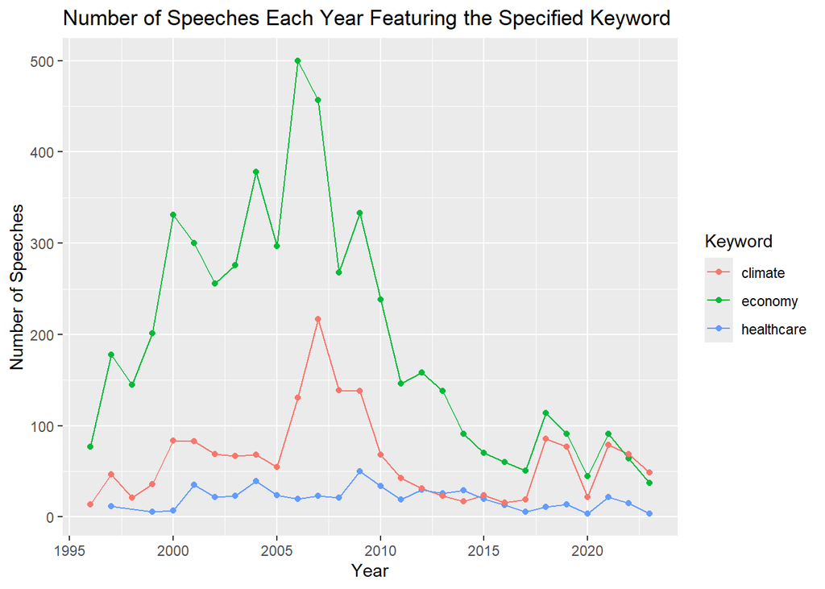

```r
library(tidyverse)
library(rvest)

keywords <- c("economy", "healthcare", "climate")

search1 <- read_html(paste0("https://datalandscapes.online/scrapeable/speeches.php?search=", keywords[1])) %>%
  html_elements(".speech_summary") %>%
  html_text2() %>%
  tibble(keyword = keywords[1],
         results = .) %>%
  separate(results, into = c("year", "num_speeches"), sep = "--") %>%
  mutate(num_speeches = parse_number(num_speeches),
         year = parse_number(year))

search2 <- read_html(paste0("https://datalandscapes.online/scrapeable/speeches.php?search=", keywords[2])) %>%
  html_elements(".speech_summary") %>%
  html_text2() %>%
  tibble(keyword = keywords[2],
         results = .) %>%
  separate(results, into = c("year", "num_speeches"), sep = "--") %>%
  mutate(num_speeches = parse_number(num_speeches),
         year = parse_number(year))

search3 <- read_html(paste0("https://datalandscapes.online/scrapeable/speeches.php?search=", keywords[3])) %>%
  html_elements(".speech_summary") %>%
  html_text2() %>%
  tibble(keyword = keywords[3],
         results = .) %>%
  separate(results, into = c("year", "num_speeches"), sep = "--") %>%
  mutate(num_speeches = parse_number(num_speeches),
         year = parse_number(year))

# combine the searches into one data frame
combined_search <- bind_rows(search1, search2, search3)
speeches_governments <- read_csv("https://docs.google.com/spreadsheets/d/e/2PACX-1vRHTFJcFmsIkjaFUCEwFWASaBOAR4X2Upx66C5Bhgc_WNc2JxxdRbbvyoewmvt_EjNdCNZZzzkENwLg/pub?gid=0&single=true&output=csv")

# Join the search data with the speeches data by year
speech_data <- left_join(combined_search, speeches_governments, by = "year")


ggplot(speech_data, aes(x = year, y = num_speeches, color = keyword)) +
  geom_line() +
  geom_point() +
  labs(title = "Number of Speeches Each Year Featuring the Specified Keyword",
       x = "Year",
       y = "Number of Speeches",
       color = "Keyword")
```

#### One sentance that my visualisation reveals…

I chose three key words that I believe represented highly differing components of government, all of much importance, and I found that the trends differed highly from what I expected except for the spike from the recession; I believed talk of climate would increase in speeches, COVID would cause a spike in healthcare talk, and economy wouldn’t be absurdly more prominent in speeches - teaching me, somewhat shockingly, that for better or worse, economy is at the forefront of the issues attended to in speeches from those leading New Zealand for many years over topics such as healthcare and climate, until very recently!

## Learning reflection

#### **One** important idea I learned from module 5…

The topic of web scraping is the most interesting and useful thing I have learnt from any paper I have taken yet. It gives real world, somewhat limitless, exploration of the biggest data set possible- the internet. This allows so much more exploration of various topics and I believe ties together many of the skill we have learnt so far with a neat bow, letting us create our own data sets from pages that we can explore as much as we wish. Explore with the other skill we have learnt prior. So for me it would definitely be the use of the rvest package.

#### I want to explore further…

The things I want to explore further is simply the application of scraping data and seeing what I can gather from that. The speech data is honestly mind blowing in how you can create a clear visualisation using keywords to show at a glance what politicians may be over/under valuing in their speeches (depending on opinion of course). A much more basic and possibly less important exploration I did myself after scraping IMDb data was to view the possible attributes that could lead to a higher score, such as run time and age rating. Honestly, at the risk of sounding excessive, it makes statistics feel like the tangible thing it always was meant to feel like, instead of the pre-generated static analysis of (sometimes irrelevant) uninteresting data that had been my experience prior.

## Self review

#### The skills I have developed when I look back on the course

The use of R to analyse data has taught me a great number of things. Most importantly though in my opinion, it has taught me to view statistics in a very different way than I used to. I saw data as much more inaccessible, something that had to be surveyed for, or was kept by groups of people for personal use, not something I could look at and learn myself. The ability to gather my own data from a range of sources is the skill I most cherish from this course. That new ability is closely followed by the possibility of visualising that data in a compact and quickly interpretable way.

The most broad learning outcome of undertaking a broad variety of data science challenges using R is the learning outcome I believe best describes my experience in the course. Because there were a great number of data challenges that I worked through using a coding language, making me appreciate both R and statistics more. As a CompSci major, this was something I was somewhat nervous to approach, thinking my enjoyment of the coding aspect would carry me through the course, I was very wrong. The data analysis side so much more interesting to me, and has prompted me to consider adjusting my course plan to explore the topic further.